# Notebook

##### Ensure kernel is set to Python 3.8 azureML

##### Add libraries used for Data Analysis

```python
#Importing necesswry libraires including numpy and pandas
import pandas as pd
import numpy as np
import matplotlib.pyplot as plt
from sklearn.model_selection import train_test_split
from sklearn.metrics import mean_squared_error
from sklearn.metrics import accuracy_score, confusion_matrix, classification_report
from sklearn.linear_model import LinearRegression
from sklearn.linear_model import LogisticRegression
import nbformat
from nbconvert import HTMLExporter
```

```python
# Assuming you've loaded the dataset into a DataFrame named 'df'
# Replace 'your_dataset.csv' with your actual dataset file path if you're loading it from a file
dfUtd = pd.read_csv('Manchester_United_Match_Results_Under_ETH_Versus_ManCity_Guardiola_First_Three_SeasonsVersusKlopp.csv', encoding='ISO-8859-1') #

print(dfUtd.columns)
print()
print("===========================================================================================================")
print()
print(dfUtd)
```

```
Index(['Date', 'Competition', 'Home Team', 'Home Score', 'Away Team',
       'Away Score', 'Result', 'Wins', 'Losses', 'Draws', 'Win Percentage'],
      dtype='object')

===========================================================================================================

           Date     Competition       Home Team Home Score       Away Team  \
0    13/08/2022  Premier League      Man United          1        Brighton
1    22/08/2022  Premier League       Brentford          4      Man United
2    27/08/2022  Premier League      Man United          2       Liverpool
3    01/09/2022  Premier League     Southampton          0      Man United
4    04/09/2022  Premier League  Leicester City          0      Man United
..          ...             ...             ...        ...             ...
327  28/04/2019  Premier League        Man City          1  Leicester City
328  06/05/2019  Premier League        Brighton          1        Man City
329  12/05/2019  FA Cup · Final        Man City          6         Watford
330         NaN             NaN             NaN        NaN             NaN
331         NaN             NaN             NaN        NaN             NaN

    Away Score Result  Wins  Losses  Draws  Win Percentage
0            2      L  75.0    43.0   18.0          55.147
1            0      L   NaN     NaN    NaN             NaN
2            1      W   NaN     NaN    NaN             NaN
3            1      W   NaN     NaN    NaN             NaN
4            1      W   NaN     NaN    NaN             NaN
..         ...    ...   ...     ...    ...             ...
327          0      W   NaN     NaN    NaN             NaN
328          4      W   NaN     NaN    NaN             NaN
329          0      W   NaN     NaN    NaN             NaN
330        NaN    NaN   NaN     NaN    NaN             NaN
331        NaN    NaN   NaN     NaN    NaN          54.650

[332 rows x 11 columns]
```

```python
print(dfUtd.columns)
print()
print("===========================================================================================================")
print()
print(dfUtd)
```

```
Index(['Date', 'Competition', 'Home Team', 'Home Score', 'Away Team',
       'Away Score', 'Result', 'Wins', 'Losses', 'Draws', 'Win Percentage'],
      dtype='object')

===========================================================================================================

           Date     Competition       Home Team Home Score       Away Team  \
0    13/08/2022  Premier League      Man United          1        Brighton
1    22/08/2022  Premier League       Brentford          4      Man United
2    27/08/2022  Premier League      Man United          2       Liverpool
3    01/09/2022  Premier League     Southampton          0      Man United
4    04/09/2022  Premier League  Leicester City          0      Man United
..          ...             ...             ...        ...             ...
327  28/04/2019  Premier League        Man City          1  Leicester City
328  06/05/2019  Premier League        Brighton          1        Man City
329  12/05/2019  FA Cup · Final        Man City          6         Watford
330         NaN             NaN             NaN        NaN             NaN
331         NaN             NaN             NaN        NaN             NaN

    Away Score Result  Wins  Losses  Draws  Win Percentage
0            2      L  75.0    43.0   18.0          55.147
1            0      L   NaN     NaN    NaN             NaN
2            1      W   NaN     NaN    NaN             NaN
3            1      W   NaN     NaN    NaN             NaN
4            1      W   NaN     NaN    NaN             NaN
..         ...    ...   ...     ...    ...             ...
327          0      W   NaN     NaN    NaN             NaN
328          4      W   NaN     NaN    NaN             NaN
329          0      W   NaN     NaN    NaN             NaN
330        NaN    NaN   NaN     NaN    NaN             NaN
331        NaN    NaN   NaN     NaN    NaN          54.650

[332 rows x 11 columns]
```

Data is clean as this data set was created by manually copying the data from Google which shows all Manchester Uniteds Previous results.

#### United vs City all competitions win percentage

Note: ETH is an abbreivation for their former Manager Eric Ten Hag Note: The comparision between ETH and Manchester City Manager Pep Guardiola is not even because ETH was sacked by Manchester United early this season.

The timeframe of comparing ETH versus Guardiola is 2.25 seasons for ETH, 3 full seasosn for Guardiola. Guardiola has the upperhand statistically as Manchester City have played more games than ETH with Manchester United which will have an influence on factors that will be analysed later in the file such as goals scored against opponents, this will likely be a lot higher for Manchester City than Manchester United.

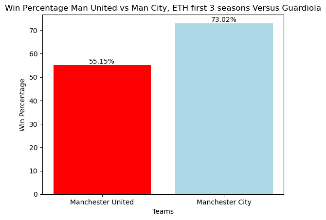

```python
# Filter the data for Manchester United and Manchester City
teams = dfUtd[(dfUtd['Home Team'].str.contains('Man United')) | (dfUtd['Home Team'].str.contains('Man City'))]

# Extract the team names and win percentages
team_names = ['Manchester United', 'Manchester City']
win_percentages = [
    teams[teams['Home Team'] == 'Man United']['Win Percentage'].mean(),  # Average win percentage for Man United
    teams[teams['Home Team'] == 'Man City']['Win Percentage'].mean()  # Average win percentage for Man City
]

# Create the bar chart
bars = plt.bar(team_names, win_percentages, color=['red', 'lightblue'], label=['Manchester United', 'Manchester City'])

# Adding labels and title
plt.xlabel('Teams')
plt.ylabel('Win Percentage')
plt.title('Win Percentage Man United vs Man City, ETH first 3 seasons Versus Guardiola')

# Display the precise win percentage above the bars
for bar in bars:
    yval = bar.get_height()
    plt.text(bar.get_x() + bar.get_width()/2, yval, f'{yval:.2f}%', ha='center', va='bottom')

# Display the bar chart
plt.show()
```

#### Total wins, Draws Losses for Manchester United under ETH

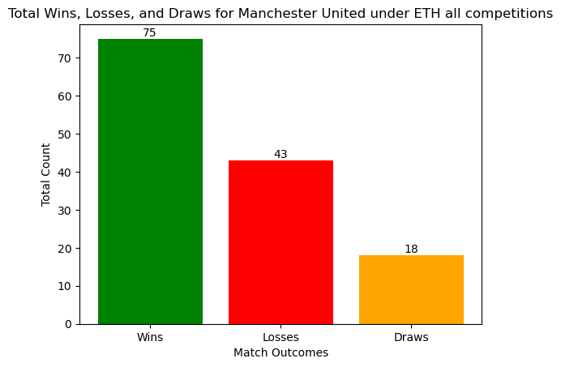

```python
# Using the previous dfUtd variable for Manchester United data
man_united_data = dfUtd[dfUtd['Home Team'] == 'Man United']

# Summing up wins, losses, and draws for Manchester United
total_wins = man_united_data['Wins'].sum()
total_losses = man_united_data['Losses'].sum()
total_draws = man_united_data['Draws'].sum()

# Data for the bar chart
categories = ['Wins', 'Losses', 'Draws']
totals = [total_wins, total_losses, total_draws]

# Create the bar chart using dfUtd data
plt.bar(categories, totals, color=['green', 'red', 'orange'])

# Adding labels and title
plt.xlabel('Match Outcomes')
plt.ylabel('Total Count')
plt.title('Total Wins, Losses, and Draws for Manchester United under ETH all competitions')

# Display the totals above each bar
for i, total in enumerate(totals):
    plt.text(i, total, f'{total:.0f}', ha='center', va='bottom')

# Show the bar chart
plt.show()
```

#### Total wins, Draws Losses for Manchester City under Pep Guardiola

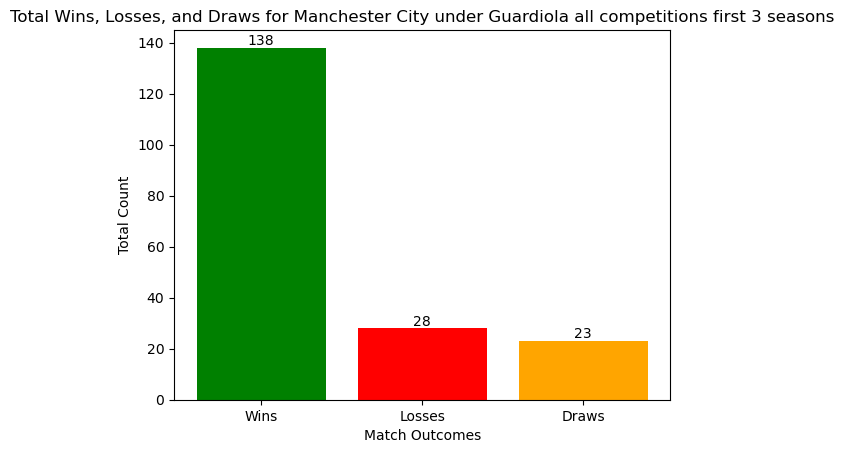

```python
# Using the previous dfUtd variable for Manchester Man City data
man_city_data = dfUtd[dfUtd['Home Team'] == 'Man City']

# Summing up wins, losses, and draws for Manchester United
total_wins_city = man_city_data['Wins'].sum()
total_losses_city = man_city_data['Losses'].sum()
total_draws_city = man_city_data['Draws'].sum()

# Data for the bar chart
categories = ['Wins', 'Losses', 'Draws']
totals = [total_wins_city, total_losses_city, total_draws_city]

# Create the bar chart using dfUtd data
plt.bar(categories, totals, color=['green', 'red', 'orange'])

# Adding labels and title
plt.xlabel('Match Outcomes')
plt.ylabel('Total Count')
plt.title('Total Wins, Losses, and Draws for Manchester City under Guardiola all competitions first 3 seasons')

# Display the totals above each bar
for i, total in enumerate(totals):
    plt.text(i, total, f'{total:.0f}', ha='center', va='bottom')

# Show the bar chart
plt.show()
```

#### United wins in the premier league only

Note: Number of Games are disprooportionate because Man United have only begun their 3rd season with ETH.

```python
# Filter Premier League games for Manchester United from dfUtd
dfUnited = dfUtd[(dfUtd['Competition'] == 'Premier League') &
                 ((dfUtd['Home Team'] == 'Man United') | (dfUtd['Away Team'] == 'Man United'))]

# Filter Premier League games for Manchester City from dfUtd
dfCity = dfUtd[(dfUtd['Competition'] == 'Premier League') &
               ((dfUtd['Home Team'] == 'Man City') | (dfUtd['Away Team'] == 'Man City'))]

# Count total games played by Manchester United and Manchester City in the Premier League
united_games_played = len(dfUnited)
city_games_played = len(dfCity)

# Print the total games played
print(f"Total Premier League games played by Manchester United: {united_games_played}")
print(f"Total Premier League games played by Manchester City: {city_games_played}")

# Count Wins, Draws, and Losses for Manchester United
united_wins = len(dfUnited[dfUnited['Result'] == 'W'])
united_draws = len(dfUnited[dfUnited['Result'] == 'D'])
united_losses = len(dfUnited[dfUnited['Result'] == 'L'])

# Data for Manchester United Premier League results
categories = ['Wins', 'Draws', 'Losses']
values = [united_wins, united_draws, united_losses]
```

```
Total Premier League games played by Manchester United: 87
Total Premier League games played by Manchester City: 125
```

#### Break down of Premier League wins draws and losses for Manchester United

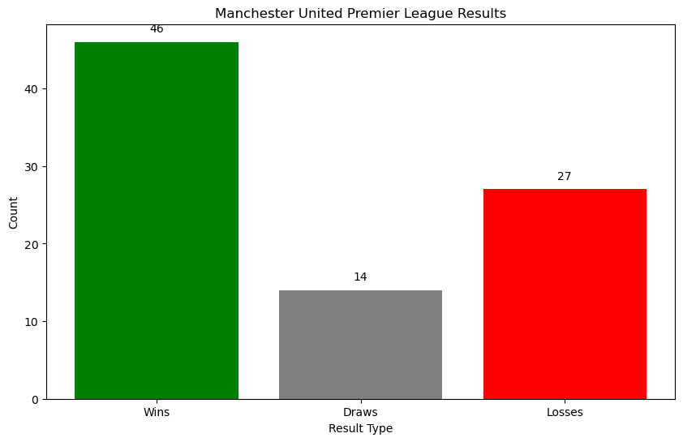

```python
# Filter Premier League games for Manchester United from dfUtd
dfUnited = dfUtd[(dfUtd['Competition'] == 'Premier League') &
                 ((dfUtd['Home Team'] == 'Man United') | (dfUtd['Away Team'] == 'Man United'))]

# Count Wins, Draws, and Losses for Manchester United
united_wins = len(dfUnited[dfUnited['Result'] == 'W'])
united_draws = len(dfUnited[dfUnited['Result'] == 'D'])
united_losses = len(dfUnited[dfUnited['Result'] == 'L'])

# Data for Manchester United Premier League results
categories = ['Wins', 'Draws', 'Losses']
values = [united_wins, united_draws, united_losses]

# Create the bar chart
plt.figure(figsize=(10, 6))
bars = plt.bar(categories, values, color=['green','grey','red'])

# Add the number of wins, draws, losses above each bar
for bar in bars:
    yval = bar.get_height()
    plt.text(bar.get_x() + bar.get_width()/2, yval + 1, int(yval), ha='center', va='bottom')

# Add titles and labels
plt.title('Manchester United Premier League Results')
plt.xlabel('Result Type')
plt.ylabel('Count')

# Display the chart
plt.show()
```

#### Break down of Premier League wins draws and losses for Manchester City

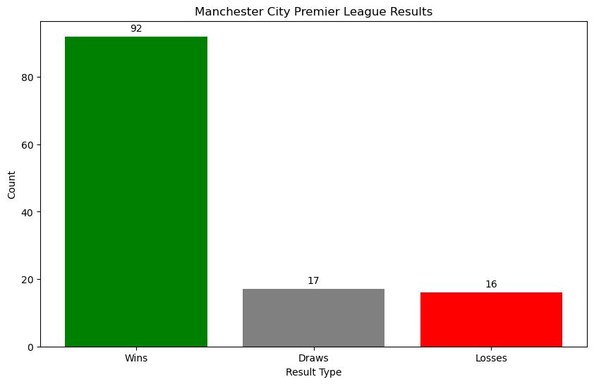

```python
# Filter Premier League games for Manchester City from dfUtd
dfCity = dfUtd[(dfUtd['Competition'] == 'Premier League') &
               ((dfUtd['Home Team'] == 'Man City') | (dfUtd['Away Team'] == 'Man City'))]

# Count Wins, Draws, and Losses for Manchester City
city_wins = len(dfCity[dfCity['Result'] == 'W'])
city_draws = len(dfCity[dfCity['Result'] == 'D'])
city_losses = len(dfCity[dfCity['Result'] == 'L'])

# Data for Manchester City Premier League results
categories = ['Wins', 'Draws', 'Losses']
values = [city_wins, city_draws, city_losses]

# Create the bar chart
plt.figure(figsize=(10, 6))
bars = plt.bar(categories, values, color=['green','grey','red'])

# Add the number of wins, draws, losses above each bar
for bar in bars:
    yval = bar.get_height()
    plt.text(bar.get_x() + bar.get_width()/2, yval + 1, int(yval), ha='center', va='bottom')

# Add titles and labels
plt.title('Manchester City Premier League Results')
plt.xlabel('Result Type')
plt.ylabel('Count')

# Display the chart
plt.show()
```

```python
# Filter Premier League games for Manchester United from dfUtd
dfUnited = dfUtd[(dfUtd['Competition'] == 'Premier League') &
                 ((dfUtd['Home Team'] == 'Man United') | (dfUtd['Away Team'] == 'Man United'))]

# Filter Premier League games for Manchester City from dfUtd
dfCity = dfUtd[(dfUtd['Competition'] == 'Premier League') &
               ((dfUtd['Home Team'] == 'Man City') | (dfUtd['Away Team'] == 'Man City'))]

# Count Wins for Manchester United and Manchester City
united_wins = len(dfUnited[dfUnited['Result'] == 'W'])
city_wins = len(dfCity[dfCity['Result'] == 'W'])

# Count total games played by Manchester United and Manchester City in the Premier League
united_games_played = len(dfUnited)
city_games_played = len(dfCity)

# Calculate win percentages
united_win_percentage = (united_wins / united_games_played) * 100 if united_games_played > 0 else 0
city_win_percentage = (city_wins / city_games_played) * 100 if city_games_played > 0 else 0

# Print win percentages
print(f"Manchester United Win Percentage in Premier League: {united_win_percentage:.2f}%")
print(f"Manchester City Win Percentage in Premier League: {city_win_percentage:.2f}%")
```

```
Manchester United Win Percentage in Premier League: 52.87%
Manchester City Win Percentage in Premier League: 73.60%
```

```
Manchester United Win Percentage in Premier League: 52.87%
Manchester City Win Percentage in Premier League: 73.60%
```

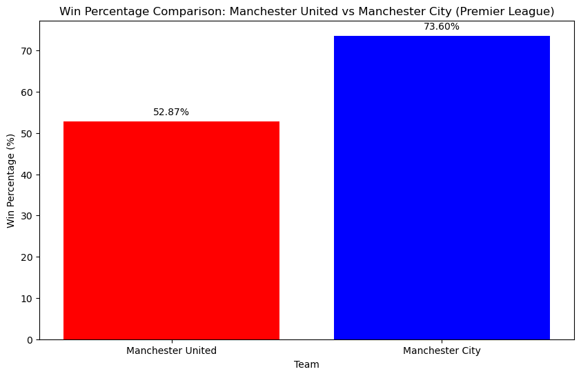

```python
# Print win percentages
print(f"Manchester United Win Percentage in Premier League: {united_win_percentage:.2f}%")
print(f"Manchester City Win Percentage in Premier League: {city_win_percentage:.2f}%")

# Create a bar chart to compare win percentages
teams = ['Manchester United', 'Manchester City']
win_percentages = [united_win_percentage, city_win_percentage]

plt.figure(figsize=(10, 6))
bars = plt.bar(teams, win_percentages, color=['red', 'blue'])

# Add the win percentage figures above each bar
for bar in bars:
    yval = bar.get_height()
    plt.text(bar.get_x() + bar.get_width()/2, yval + 1, f'{yval:.2f}%', ha='center', va='bottom')

# Add titles and labels
plt.title('Win Percentage Comparison: Manchester United vs Manchester City (Premier League)')
plt.xlabel('Team')
plt.ylabel('Win Percentage (%)')

# Display the chart
plt.show()
```

#### Comparing win percentage in alternative competitions ie. FA Cup, Champions League, Europa League

```
Manchester United Win Percentage in Other Competitions: 57.63%
Manchester City Win Percentage in Other Competitions: 64.47%
Total games played by Manchester United in Other Competitions: 59
Total games played by Manchester City in Other Competitions: 76
```

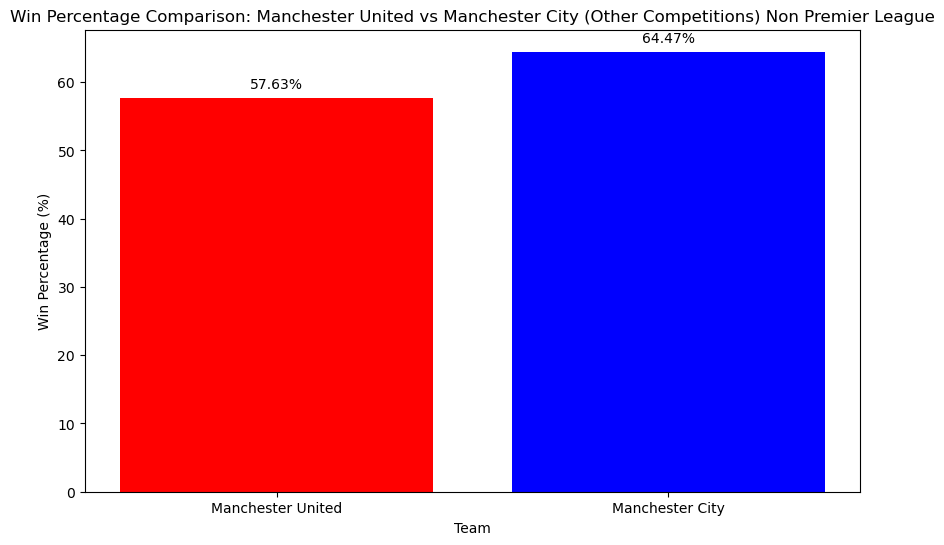

```python
# Filter non-Premier League games for Manchester United from dfUtd
dfUnited_other = dfUtd[(dfUtd['Competition'] != 'Premier League') &
                      ((dfUtd['Home Team'] == 'Man United') | (dfUtd['Away Team'] == 'Man United'))]

# Filter non-Premier League games for Manchester City from dfUtd
dfCity_other = dfUtd[(dfUtd['Competition'] != 'Premier League') &
                    ((dfUtd['Home Team'] == 'Man City') | (dfUtd['Away Team'] == 'Man City'))]

# Count Wins for Manchester United and Manchester City in other competitions
united_other_wins = len(dfUnited_other[dfUnited_other['Result'] == 'W'])
city_other_wins = len(dfCity_other[dfCity_other['Result'] == 'W'])

# Count total games played by Manchester United and Manchester City in other competitions
united_other_games_played = len(dfUnited_other)
city_other_games_played = len(dfCity_other)

# Calculate win percentages for other competitions
united_other_win_percentage = (united_other_wins / united_other_games_played) * 100 if united_other_games_played > 0 else 0
city_other_win_percentage = (city_other_wins / city_other_games_played) * 100 if city_other_games_played > 0 else 0

# Print win percentages and total games played
print(f"Manchester United Win Percentage in Other Competitions: {united_other_win_percentage:.2f}%")
print(f"Manchester City Win Percentage in Other Competitions: {city_other_win_percentage:.2f}%")
#print("Total premier league games for Manchester United : 87")
#print("Total premier league games for Manchester  Manchester City : 125")
print(f"Total games played by Manchester United in Other Competitions: {united_other_games_played}")
print(f"Total games played by Manchester City in Other Competitions: {city_other_games_played}")

# Create a bar chart to compare win percentages in other competitions
teams = ['Manchester United', 'Manchester City']
other_win_percentages = [united_other_win_percentage, city_other_win_percentage]

plt.figure(figsize=(10, 6))
bars = plt.bar(teams, other_win_percentages, color=['red', 'blue'])

# Add the win percentage figures above each bar
for bar in bars:
    yval = bar.get_height()
    plt.text(bar.get_x() + bar.get_width()/2, yval + 1, f'{yval:.2f}%', ha='center', va='bottom')

# Add titles and labels
plt.title('Win Percentage Comparison: Manchester United vs Manchester City (Other Competitions) Non Premier League')
plt.xlabel('Team')
plt.ylabel('Win Percentage (%)')

# Display the chart
plt.show()
```

#### Comparing number of champions league games and win percentage

```
Manchester United Win Percentage in Champions League: 16.67%
Manchester City Win Percentage in Champions League: 61.11%
Total games played by Manchester United in Champions League: 6
Total games played by Manchester City in Champions League: 36
```

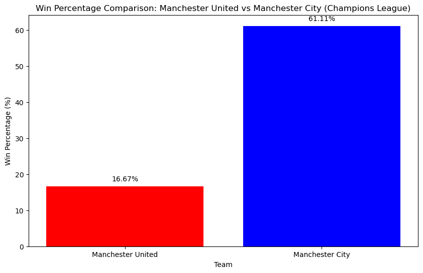

```python
# Filter Champions League games for Manchester United from dfUtd
dfUnited_cl = dfUtd[dfUtd['Competition'].str.contains('UEFA Champions League', case=False, na=False) &
                    ((dfUtd['Home Team'] == 'Man United') | (dfUtd['Away Team'] == 'Man United'))]

# Filter Champions League games for Manchester City from dfUtd
dfCity_cl = dfUtd[dfUtd['Competition'].str.contains('UEFA Champions League', case=False, na=False) &
                  ((dfUtd['Home Team'] == 'Man City') | (dfUtd['Away Team'] == 'Man City'))]

# Count Wins for Manchester United and Manchester City in Champions League
united_cl_wins = len(dfUnited_cl[dfUnited_cl['Result'] == 'W'])
city_cl_wins = len(dfCity_cl[dfCity_cl['Result'] == 'W'])

# Count total games played by Manchester United and Manchester City in Champions League
united_cl_games_played = len(dfUnited_cl)
city_cl_games_played = len(dfCity_cl)

# Calculate win percentages for Champions League
united_cl_win_percentage = (united_cl_wins / united_cl_games_played) * 100 if united_cl_games_played > 0 else 0
city_cl_win_percentage = (city_cl_wins / city_cl_games_played) * 100 if city_cl_games_played > 0 else 0

# Print win percentages and total games played
print(f"Manchester United Win Percentage in Champions League: {united_cl_win_percentage:.2f}%")
print(f"Manchester City Win Percentage in Champions League: {city_cl_win_percentage:.2f}%")
print(f"Total games played by Manchester United in Champions League: {united_cl_games_played}")
print(f"Total games played by Manchester City in Champions League: {city_cl_games_played}")

# Create a bar chart to compare win percentages in Champions League
teams = ['Manchester United', 'Manchester City']
cl_win_percentages = [united_cl_win_percentage, city_cl_win_percentage]

plt.figure(figsize=(10, 6))
bars = plt.bar(teams, cl_win_percentages, color=['red', 'blue'])

# Add the win percentage figures above each bar
for bar in bars:
    yval = bar.get_height()
    plt.text(bar.get_x() + bar.get_width()/2, yval + 1, f'{yval:.2f}%', ha='center', va='bottom')

# Add titles and labels
plt.title('Win Percentage Comparison: Manchester United vs Manchester City (Champions League)')
plt.xlabel('Team')
plt.ylabel('Win Percentage (%)')

# Display the chart
plt.show()
```

#### Statistical results

```python
# Calculate total count of goals and average goals per game for Manchester United
total_goals = 0

def calculate_goals(row):
    try:
        if row['Home Team'] == 'Man United':
            return int(row['Home Score'].split()[0])
        elif row['Away Team'] == 'Man United':
            return int(row['Away Score'].split()[0])
    except ValueError:
        return 0
    return 0

# Apply function to calculate goals scored by Manchester United
dfUtd['United Goals'] = dfUtd.apply(calculate_goals, axis=1)

total_goals = dfUtd['United Goals'].sum()
number_of_games = len(dfUtd[(dfUtd['Home Team'] == 'Man United') | (dfUtd['Away Team'] == 'Man United')])
average_goals_per_game = total_goals / number_of_games if number_of_games > 0 else 0

# Print total count of goals and average goals per game
print(f"Total goals scored by Manchester United: {total_goals}")
print(f"Average goals per game scored by Manchester United: {average_goals_per_game:.2f}")
```

```
Total goals scored by Manchester United: 229
Average goals per game scored by Manchester United: 1.57
```

```python
# Calculate total count of goals and average goals per game for Manchester City
total_goals_city = 0

def calculate_goals_city(row):
    try:
        if row['Home Team'] == 'Man City':
            return int(row['Home Score'].split()[0])
        elif row['Away Team'] == 'Man City':
            return int(row['Away Score'].split()[0])
    except ValueError:
        return 0
    return 0

# Apply function to calculate goals scored by Manchester City
dfUtd['City Goals'] = dfUtd.apply(calculate_goals_city, axis=1)

total_goals_city = dfUtd['City Goals'].sum()
number_of_games_city = len(dfUtd[(dfUtd['Home Team'] == 'Man City') | (dfUtd['Away Team'] == 'Man City')])

average_goals_per_game_city = total_goals_city / number_of_games_city if number_of_games_city > 0 else 0

# Print total count of goals and average goals per game for Manchester City
print(f"Total goals scored by Manchester City: {total_goals_city}")
print(f"Average goals per game scored by Manchester City: {average_goals_per_game_city:.2f}")
```

```
Total goals scored by Manchester City: 492
Average goals per game scored by Manchester City: 2.45
```

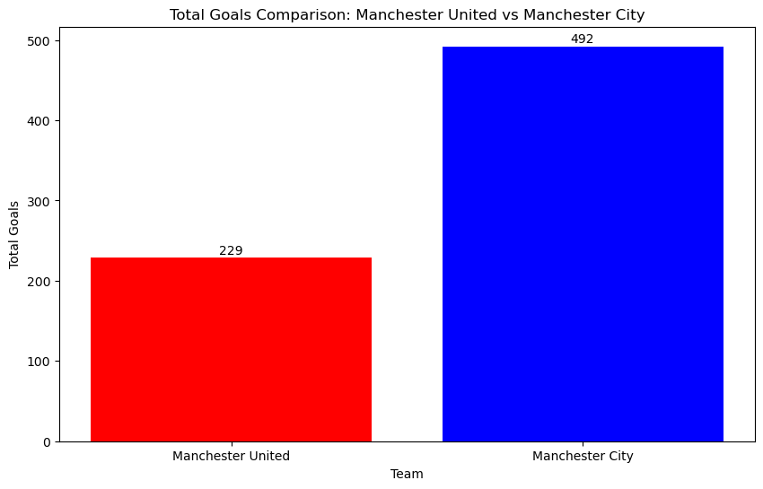

```python
# Create a bar chart to compare total goals between Manchester United and Manchester City
total_goals_united = dfUtd['United Goals'].sum()
total_goals_city = dfUtd['City Goals'].sum()

teams = ['Manchester United', 'Manchester City']
goals = [total_goals_united, total_goals_city]

plt.figure(figsize=(10, 6))
bars = plt.bar(teams, goals, color=['red', 'blue'])

# Add the total goals above each bar
for bar in bars:
    yval = bar.get_height()
    plt.text(bar.get_x() + bar.get_width()/2, yval + 1, f'{yval}', ha='center', va='bottom')

# Add titles and labels
plt.title('Total Goals Comparison: Manchester United vs Manchester City')
plt.xlabel('Team')
plt.ylabel('Total Goals')

# Display the chart
plt.show()
```

#### Average goals per game for Manchester United and Manchester City

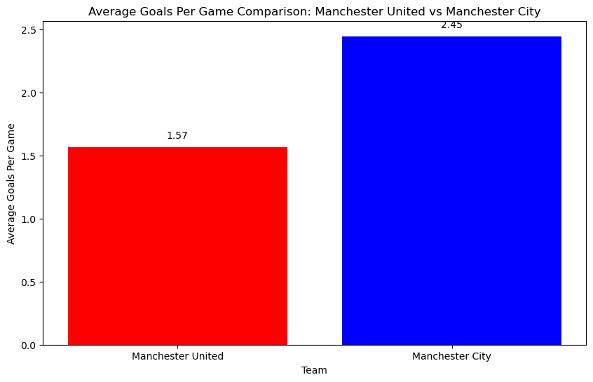

```python
# Calculate average goals per game for Manchester United and Manchester City
number_of_games_united = len(dfUtd[(dfUtd['Home Team'] == 'Man United') | (dfUtd['Away Team'] == 'Man United')])
number_of_games_city = len(dfUtd[(dfUtd['Home Team'] == 'Man City') | (dfUtd['Away Team'] == 'Man City')])

total_goals_united = dfUtd['United Goals'].sum()
total_goals_city = dfUtd['City Goals'].sum()

average_goals_per_game_united = total_goals_united / number_of_games_united if number_of_games_united > 0 else 0
average_goals_per_game_city = total_goals_city / number_of_games_city if number_of_games_city > 0 else 0

# Create a bar chart to compare average goals per game between Manchester United and Manchester City
teams = ['Manchester United', 'Manchester City']
average_goals = [average_goals_per_game_united, average_goals_per_game_city]

plt.figure(figsize=(10, 6))
bars = plt.bar(teams, average_goals, color=['red', 'blue'])

# Add the average goals per game above each bar
for bar in bars:
    yval = bar.get_height()
    plt.text(bar.get_x() + bar.get_width()/2, yval + 0.05, f'{yval:.2f}', ha='center', va='bottom')

# Add titles and labels
plt.title('Average Goals Per Game Comparison: Manchester United vs Manchester City')
plt.xlabel('Team')
plt.ylabel('Average Goals Per Game')

# Display the chart
plt.show()
```

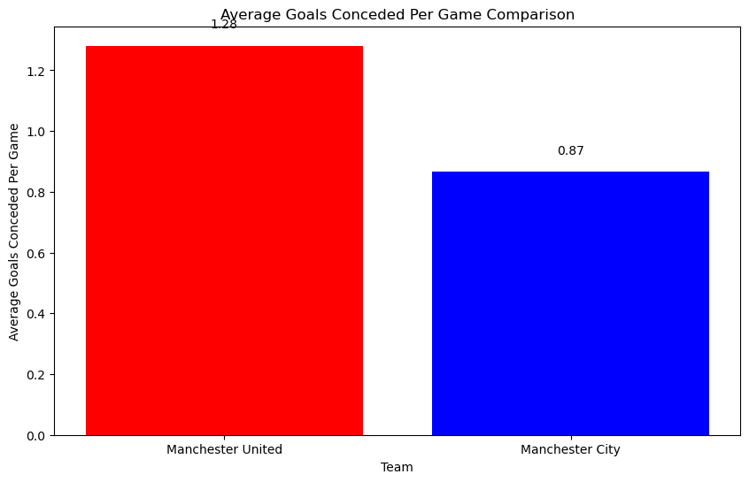

```python
# Calculate total goals conceded for Manchester United and Manchester City
def calculate_goals_conceded_united(row):
    try:
        if row['Home Team'] == 'Man United':
            return int(row['Away Score'].split()[0])
        elif row['Away Team'] == 'Man United':
            return int(row['Home Score'].split()[0])
    except ValueError:
        return 0
    return 0

def calculate_goals_conceded_city(row):
    try:
        if row['Home Team'] == 'Man City':
            return int(row['Away Score'].split()[0])
        elif row['Away Team'] == 'Man City':
            return int(row['Home Score'].split()[0])
    except ValueError:
        return 0
    return 0

dfUtd['United Goals Conceded'] = dfUtd.apply(calculate_goals_conceded_united, axis=1)
dfUtd['City Goals Conceded'] = dfUtd.apply(calculate_goals_conceded_city, axis=1)

total_goals_conceded_united = dfUtd['United Goals Conceded'].sum()
total_goals_conceded_city = dfUtd['City Goals Conceded'].sum()

number_of_games_united = len(dfUtd[(dfUtd['Home Team'] == 'Man United') | (dfUtd['Away Team'] == 'Man United')])
number_of_games_city = len(dfUtd[(dfUtd['Home Team'] == 'Man City') | (dfUtd['Away Team'] == 'Man City')])

average_goals_conceded_per_game_united = total_goals_conceded_united / number_of_games_united if number_of_games_united > 0 else 0
average_goals_conceded_per_game_city = total_goals_conceded_city / number_of_games_city if number_of_games_city > 0 else 0

# Create a bar chart to compare average goals conceded per game between Manchester United and Manchester City
teams = ['Manchester United', 'Manchester City']
average_goals_conceded = [average_goals_conceded_per_game_united, average_goals_conceded_per_game_city]

plt.figure(figsize=(10, 6))
bars = plt.bar(teams, average_goals_conceded, color=['red', 'blue'])

# Add the average goals conceded per game above each bar
for bar in bars:
    yval = bar.get_height()
    plt.text(bar.get_x() + bar.get_width()/2, yval + 0.05, f'{yval:.2f}', ha='center', va='bottom')

# Add titles and labels
plt.title('Average Goals Conceded Per Game Comparison')
plt.xlabel('Team')
plt.ylabel('Average Goals Conceded Per Game')

# Display the chart
plt.show()
```

# United compared to City vs the top 6

```python
# Calculate the total number of games Manchester United and Manchester City have played against the top 5 teams in the Premier League

top_5_teams = ['Arsenal', 'Liverpool', 'Tottenham', 'Chelsea', 'Man City']

# Filter for Manchester United games in the Premier League against top 5 teams excluding Man United
dfUnited_top5 = dfUtd[(dfUtd['Competition'] == 'Premier League') &
                     ((dfUtd['Home Team'] == 'Man United') & (dfUtd['Away Team'].isin(top_5_teams))) |
                     ((dfUtd['Away Team'] == 'Man United') & (dfUtd['Home Team'].isin(top_5_teams)))]

# Filter for Manchester City games in the Premier League against top 5 teams excluding Man City
top_5_teams_city = ['Arsenal', 'Liverpool', 'Tottenham', 'Chelsea', 'Man United']
dfCity_top5 = dfUtd[(dfUtd['Competition'] == 'Premier League') &
                   ((dfUtd['Home Team'] == 'Man City') & (dfUtd['Away Team'].isin(top_5_teams_city))) |
                   ((dfUtd['Away Team'] == 'Man City') & (dfUtd['Home Team'].isin(top_5_teams_city)))]

# Count the number of games played by Manchester United and Manchester City against top 5 teams
num_games_united_top5 = len(dfUnited_top5)
num_games_city_top5 = len(dfCity_top5)

# Print the number of games played
print(f"Total number of games played by Manchester United against top 5 teams: {num_games_united_top5}")
print(f"Total number of games played by Manchester City against top 5 teams: {num_games_city_top5}")
```

```
Total number of games played by Manchester United against top 5 teams: 33
Total number of games played by Manchester City against top 5 teams: 45
```

#### Total goals scored and conceded by Manchester United against top 5 teams

```
Total goals scored by Manchester United against top 5 teams: 39
Total goals conceded by Manchester United against top 5 teams: 65
Total goals scored by Manchester City against top 5 teams: 79
Total goals conceded by Manchester City against top 5 teams: 50
```

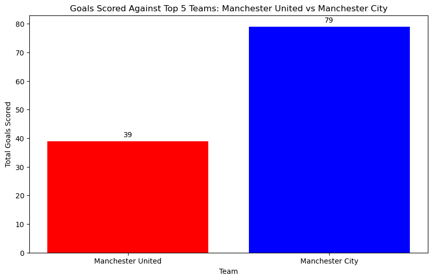

```python
# Calculate total goals scored and conceded by Manchester United against top 5 teams
def parse_score(score):
    try:
        return int(score.split()[0])
    except ValueError:
        return 0

# Apply score parsing to Manchester United
total_goals_united_scored = dfUnited_top5.apply(lambda row: parse_score(row['Home Score']) if row['Home Team'] == 'Man United' else parse_score(row['Away Score']), axis=1).sum()
total_goals_united_conceded = dfUnited_top5.apply(lambda row: parse_score(row['Away Score']) if row['Home Team'] == 'Man United' else parse_score(row['Home Score']), axis=1).sum()

# Calculate total goals scored and conceded by Manchester City against top 5 teams
total_goals_city_scored = dfCity_top5.apply(lambda row: parse_score(row['Home Score']) if row['Home Team'] == 'Man City' else parse_score(row['Away Score']), axis=1).sum()
total_goals_city_conceded = dfCity_top5.apply(lambda row: parse_score(row['Away Score']) if row['Home Team'] == 'Man City' else parse_score(row['Home Score']), axis=1).sum()

# Print total goals scored and conceded
print(f"Total goals scored by Manchester United against top 5 teams: {total_goals_united_scored}")
print(f"Total goals conceded by Manchester United against top 5 teams: {total_goals_united_conceded}")
print(f"Total goals scored by Manchester City against top 5 teams: {total_goals_city_scored}")
print(f"Total goals conceded by Manchester City against top 5 teams: {total_goals_city_conceded}")

# Create a bar chart to represent goals scored against top 5 teams
teams = ['Manchester United', 'Manchester City']
goals_scored = [total_goals_united_scored, total_goals_city_scored]

plt.figure(figsize=(10, 6))
bars = plt.bar(teams, goals_scored, color=['red', 'blue'])

# Add the total goals scored above each bar
for bar in bars:
    yval = bar.get_height()
    plt.text(bar.get_x() + bar.get_width()/2, yval + 1, f'{yval}', ha='center', va='bottom')

# Add titles and labels
plt.title('Goals Scored Against Top 5 Teams: Manchester United vs Manchester City')
plt.xlabel('Team')
plt.ylabel('Total Goals Scored')

# Display the chart
plt.show()
```

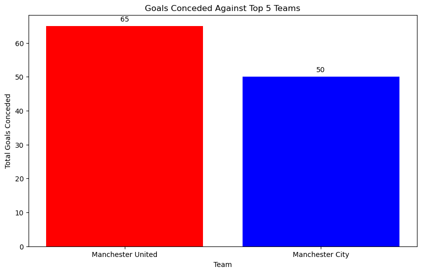

```python
# Create a bar chart to represent goals conceded against top 5 teams
goals_conceded = [total_goals_united_conceded, total_goals_city_conceded]

plt.figure(figsize=(10, 6))
bars = plt.bar(teams, goals_conceded, color=['red', 'blue'])

# Add the total goals conceded above each bar
for bar in bars:
    yval = bar.get_height()
    plt.text(bar.get_x() + bar.get_width()/2, yval + 1, f'{yval}', ha='center', va='bottom')

# Add titles and labels
plt.title('Goals Conceded Against Top 5 Teams')
plt.xlabel('Team')
plt.ylabel('Total Goals Conceded')

# Display the chart
plt.show()
```

```
Wins by Manchester United against top 5 teams: 8
Defeats by Manchester United against top 5 teams: 19
Goal difference for Manchester United against top 5 teams: -26
Wins by Manchester City against top 5 teams: 25
Defeats by Manchester City against top 5 teams: 15
Goal difference for Manchester City against top 5 teams: 29
```

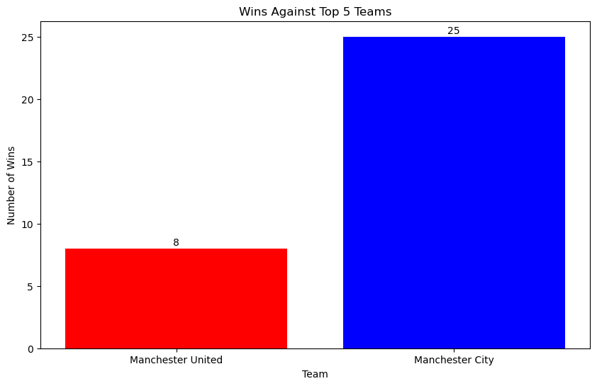

```python
# Calculate wins, defeats, and goal difference for Manchester United and Manchester City against top 5 teams

# Calculate wins and defeats for Manchester United against top 5 teams
wins_united_top5 = len(dfUnited_top5[(dfUnited_top5['Home Team'] == 'Man United') & (dfUnited_top5['Home Score'] > dfUnited_top5['Away Score'])]) + \
                   len(dfUnited_top5[(dfUnited_top5['Away Team'] == 'Man United') & (dfUnited_top5['Away Score'] > dfUnited_top5['Home Score'])])

defeats_united_top5 = len(dfUnited_top5[(dfUnited_top5['Home Team'] == 'Man United') & (dfUnited_top5['Home Score'] < dfUnited_top5['Away Score'])]) + \
                      len(dfUnited_top5[(dfUnited_top5['Away Team'] == 'Man United') & (dfUnited_top5['Away Score'] < dfUnited_top5['Home Score'])])

goal_difference_united_top5 = total_goals_united_scored - total_goals_united_conceded

# Calculate wins and defeats for Manchester City against top 5 teams
wins_city_top5 = len(dfCity_top5[(dfCity_top5['Home Team'] == 'Man City') & (dfCity_top5['Home Score'] > dfCity_top5['Away Score'])]) + \
                 len(dfCity_top5[(dfCity_top5['Away Team'] == 'Man City') & (dfCity_top5['Away Score'] > dfCity_top5['Home Score'])])

defeats_city_top5 = len(dfCity_top5[(dfCity_top5['Home Team'] == 'Man City') & (dfCity_top5['Home Score'] < dfCity_top5['Away Score'])]) + \
                    len(dfCity_top5[(dfCity_top5['Away Team'] == 'Man City') & (dfCity_top5['Away Score'] < dfCity_top5['Home Score'])])

goal_difference_city_top5 = total_goals_city_scored - total_goals_city_conceded

# Print wins, defeats, and goal difference
print(f"Wins by Manchester United against top 5 teams: {wins_united_top5}")
print(f"Defeats by Manchester United against top 5 teams: {defeats_united_top5}")
print(f"Goal difference for Manchester United against top 5 teams: {goal_difference_united_top5}")

print(f"Wins by Manchester City against top 5 teams: {wins_city_top5}")
print(f"Defeats by Manchester City against top 5 teams: {defeats_city_top5}")
print(f"Goal difference for Manchester City against top 5 teams: {goal_difference_city_top5}")

# Create bar charts to compare wins, defeats, and goal difference
teams = ['Manchester United', 'Manchester City']

# Wins comparison
wins = [wins_united_top5, wins_city_top5]
plt.figure(figsize=(10, 6))
bars = plt.bar(teams, wins, color=['red', 'blue'])
for bar in bars:
    yval = bar.get_height()
    plt.text(bar.get_x() + bar.get_width()/2, yval + 0.1, f'{yval}', ha='center', va='bottom')
plt.title('Wins Against Top 5 Teams')
plt.xlabel('Team')
plt.ylabel('Number of Wins')
plt.show()
```

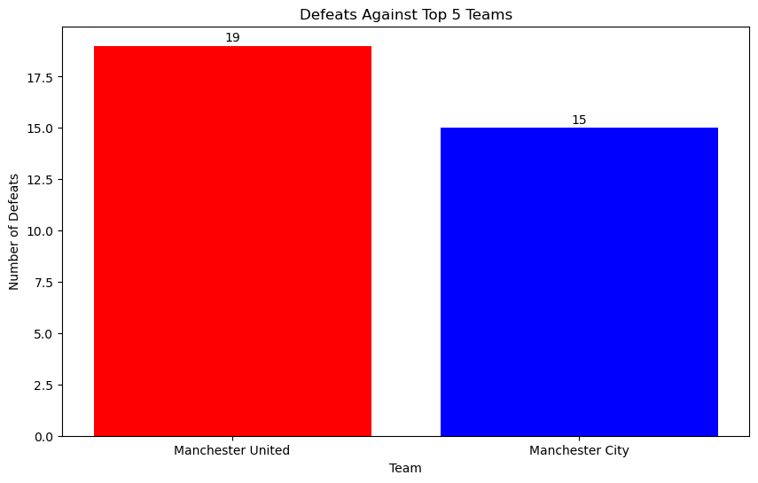

```python
# Defeats comparison
defeats = [defeats_united_top5, defeats_city_top5]
plt.figure(figsize=(10, 6))
bars = plt.bar(teams, defeats, color=['red', 'blue'])
for bar in bars:
    yval = bar.get_height()
    plt.text(bar.get_x() + bar.get_width()/2, yval + 0.1, f'{yval}', ha='center', va='bottom')
plt.title('Defeats Against Top 5 Teams')
plt.xlabel('Team')
plt.ylabel('Number of Defeats')
plt.show()
```

#### Goal difference comparison

Note: Goal Difference is the difference between goals scored versus conceded for a team. i.e, 100 goals scored and 90 goals conceded = +10 goal difference.

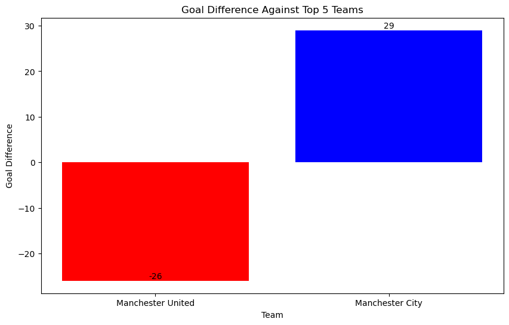

```python
# Goal difference comparison
goal_difference = [goal_difference_united_top5, goal_difference_city_top5]
plt.figure(figsize=(10, 6))
bars = plt.bar(teams, goal_difference, color=['red', 'blue'])
for bar in bars:
    yval = bar.get_height()
    plt.text(bar.get_x() + bar.get_width()/2, yval + 0.1, f'{yval}', ha='center', va='bottom')
plt.title('Goal Difference Against Top 5 Teams')
plt.xlabel('Team')
plt.ylabel('Goal Difference')
plt.show()
```

#### total number of games, goals scored, and goals conceded by Manchester United and Manchester City against the rest of the Premier League teams

```python
# Calculate the total number of games, goals scored, and goals conceded by Manchester United and Manchester City against the rest of the Premier League teams

# Define teams excluding the top 5
top_5_teams = ['Arsenal', 'Liverpool', 'Tottenham', 'Chelsea', 'Man City', 'Man United']

# Filter for Manchester United games in the Premier League against rest of the league
dfUnited_rest = dfUtd[(dfUtd['Competition'] == 'Premier League') &
                      ((dfUtd['Home Team'] == 'Man United') & (~dfUtd['Away Team'].isin(top_5_teams))) |
                      ((dfUtd['Away Team'] == 'Man United') & (~dfUtd['Home Team'].isin(top_5_teams)))]

# Filter for Manchester City games in the Premier League against rest of the league
dfCity_rest = dfUtd[(dfUtd['Competition'] == 'Premier League') &
                    ((dfUtd['Home Team'] == 'Man City') & (~dfUtd['Away Team'].isin(top_5_teams))) |
                    ((dfUtd['Away Team'] == 'Man City') & (~dfUtd['Home Team'].isin(top_5_teams)))]

# Count the number of games played by Manchester United and Manchester City against rest of the league
num_games_united_rest = len(dfUnited_rest)
num_games_city_rest = len(dfCity_rest)

# Calculate total goals scored and conceded by Manchester United against rest of the league
total_goals_united_scored_rest = dfUnited_rest.apply(lambda row: parse_score(row['Home Score']) if row['Home Team'] == 'Man United' else parse_score(row['Away Score']), axis=1).sum()
total_goals_united_conceded_rest = dfUnited_rest.apply(lambda row: parse_score(row['Away Score']) if row['Home Team'] == 'Man United' else parse_score(row['Home Score']), axis=1).sum()

# Calculate total goals scored and conceded by Manchester City against rest of the league
total_goals_city_scored_rest = dfCity_rest.apply(lambda row: parse_score(row['Home Score']) if row['Home Team'] == 'Man City' else parse_score(row['Away Score']), axis=1).sum()
total_goals_city_conceded_rest = dfCity_rest.apply(lambda row: parse_score(row['Away Score']) if row['Home Team'] == 'Man City' else parse_score(row['Home Score']), axis=1).sum()

# Print the number of games played, goals scored, and goals conceded
print(f"Total number of games played by Manchester United against rest of the league: {num_games_united_rest}")
print(f"Total goals scored by Manchester United against rest of the league: {total_goals_united_scored_rest}")
print(f"Total goals conceded by Manchester United against rest of the league: {total_goals_united_conceded_rest}")

print("")
print("")

print(f"Total number of games played by Manchester City against rest of the league: {num_games_city_rest}")
print(f"Total goals scored by Manchester City against rest of the league: {total_goals_city_scored_rest}")
print(f"Total goals conceded by Manchester City against rest of the league: {total_goals_city_conceded_rest}")
```

```
Total number of games played by Manchester United against rest of the league: 79
Total goals scored by Manchester United against rest of the league: 118
Total goals conceded by Manchester United against rest of the league: 87


Total number of games played by Manchester City against rest of the league: 122
Total goals scored by Manchester City against rest of the league: 311
Total goals conceded by Manchester City against rest of the league: 100
```

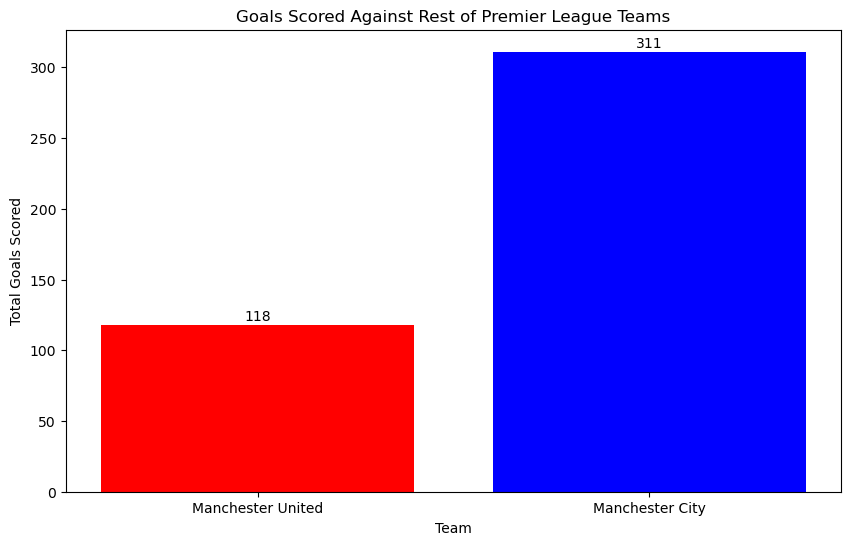

```python
# Create a bar chart to compare goals scored against rest of the league
teams = ['Manchester United', 'Manchester City']
goals_scored_rest = [total_goals_united_scored_rest, total_goals_city_scored_rest]

plt.figure(figsize=(10, 6))
bars = plt.bar(teams, goals_scored_rest, color=['red', 'blue'])

# Add the total goals scored above each bar
for bar in bars:
    yval = bar.get_height()
    plt.text(bar.get_x() + bar.get_width()/2, yval + 1, f'{yval}', ha='center', va='bottom')

# Add titles and labels
plt.title('Goals Scored Against Rest of Premier League Teams')
plt.xlabel('Team')
plt.ylabel('Total Goals Scored')

# Display the chart
plt.show()
```

#### Goals conceded

It may appear unexpected that Man City would concede more goals than Manchester United.

As mentioned about the extra games Manchester City have played versus Manchester United in this case study you would expect City to concede more goals.

More reasons include i.e., Manchester City play in the Champions and Manchester United have played in the Europa League meaning Manchester City play much higher quality teams. Manchester City tend to make it further in other cup tournaments meaning they play more games than Manchester United.

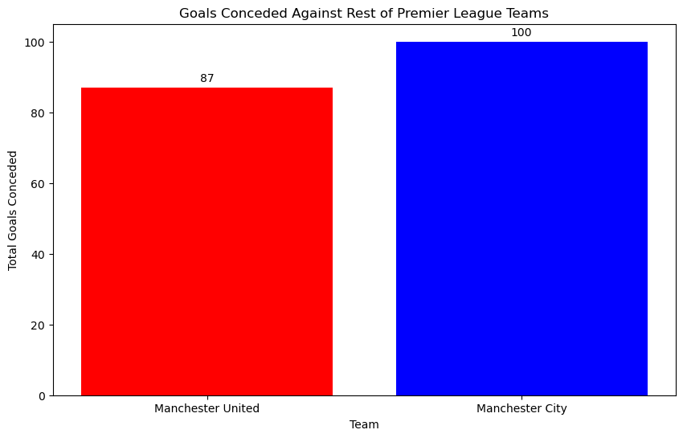

```python
# Create a bar chart to compare goals conceded against rest of the league
teams = ['Manchester United', 'Manchester City']
goals_conceded_rest = [total_goals_united_conceded_rest, total_goals_city_conceded_rest]

plt.figure(figsize=(10, 6))
bars = plt.bar(teams, goals_conceded_rest, color=['red', 'blue'])

# Add the total goals conceded above each bar
for bar in bars:
    yval = bar.get_height()
    plt.text(bar.get_x() + bar.get_width()/2, yval + 1, f'{yval}', ha='center', va='bottom')

# Add titles and labels
plt.title('Goals Conceded Against Rest of Premier League Teams')
plt.xlabel('Team')
plt.ylabel('Total Goals Conceded')

# Display the chart
plt.show()
```

#### Goal Difference

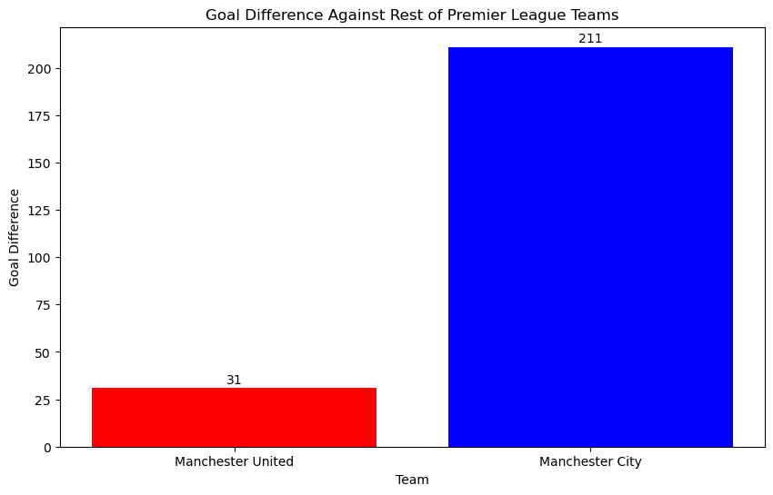

```python
# Calculate goal difference for both teams against the rest of the Premier League
goal_difference_united_rest = total_goals_united_scored_rest - total_goals_united_conceded_rest
goal_difference_city_rest = total_goals_city_scored_rest - total_goals_city_conceded_rest

# Create a bar chart to compare goal difference against rest of the league
teams = ['Manchester United', 'Manchester City']
goal_difference_rest = [goal_difference_united_rest, goal_difference_city_rest]

plt.figure(figsize=(10, 6))
bars = plt.bar(teams, goal_difference_rest, color=['red', 'blue'])

# Add the goal difference above each bar
for bar in bars:
    yval = bar.get_height()
    plt.text(bar.get_x() + bar.get_width()/2, yval + 1, f'{yval}', ha='center', va='bottom')

# Add titles and labels
plt.title('Goal Difference Against Rest of Premier League Teams')
plt.xlabel('Team')
plt.ylabel('Goal Difference')

# Display the chart
plt.show()
```

#### Checking specifics for Manchester best and worst results in the last 2.25 seasons.

(Draws included for additional context)

##### Losses

```python
# Filter the dataset to find matches where Manchester United were defeated
df_united_defeats = dfUtd[((dfUtd['Home Team'] == 'Man United') & (dfUtd['Home Score'] < dfUtd['Away Score'])) |
                          ((dfUtd['Away Team'] == 'Man United') & (dfUtd['Away Score'] < dfUtd['Home Score']))]

# Select relevant columns: Date, Team names, and score
defeat_details = df_united_defeats[['Date', 'Home Team', 'Away Team', 'Home Score', 'Away Score']]

# Print the details of teams that have defeated Manchester United
print(defeat_details)
```

```
           Date       Home Team       Away Team Home Score Away Score
0    13/08/2022      Man United        Brighton          1          2
1    22/08/2022       Brentford      Man United          4          0
5    08/09/2022      Man United   Real Sociedad          0          1
7    02/10/2022        Man City      Man United          6          3
17   06/11/2022     Aston Villa      Man United          3          1
20   07/12/2022          CÃ¡diz      Man United          4          2
21   10/12/2022      Real Betis      Man United          1          0
30   22/01/2023         Arsenal      Man United          3          2
42   05/03/2023       Liverpool      Man United          7          0
47   02/04/2023       Newcastle      Man United          2          0
52   20/04/2023         Sevilla      Man United          3          0
56   04/05/2023        Brighton      Man United          1          0
57   07/05/2023        West Ham      Man United          1          0
61   03/06/2023        Man City      Man United          2          1
```

[output cut: 34 more lines]

##### Draws

```python
# Filter the dataset to find matches where Manchester United drew
df_united_draws = dfUtd[((dfUtd['Home Team'] == 'Man United') & (dfUtd['Home Score'] == dfUtd['Away Score'])) |
                        ((dfUtd['Away Team'] == 'Man United') & (dfUtd['Away Score'] == dfUtd['Home Score']))]

# Select relevant columns: Date, Team names, and score
draw_details = df_united_draws[['Date', 'Home Team', 'Away Team', 'Home Score', 'Away Score']]

# Print the details of teams that have drawn with Manchester United
print(draw_details)
```

```
           Date       Home Team      Away Team Home Score Away Score
11   16/10/2022      Man United      Newcastle          0          0
13   22/10/2022         Chelsea     Man United          1          1
29   18/01/2023  Crystal Palace     Man United          1          1
35   08/02/2023      Man United   Leeds United          2          2
37   16/02/2023       Barcelona     Man United          2          2
44   12/03/2023      Man United    Southampton          0          0
50   13/04/2023      Man United        Sevilla          2          2
54   27/04/2023       Tottenham     Man United          2          2
69   06/08/2023      Man United  Athletic Club          1          1
89   29/11/2023     Galatasaray     Man United          3          3
94   17/12/2023       Liverpool     Man United          0          0
99   14/01/2024      Man United      Tottenham          2          2
110  30/03/2024       Brentford     Man United          1          1
112  07/04/2024      Man United      Liverpool          2          2
113  13/04/2024     Bournemouth     Man United          2          2
116  27/04/2024      Man United        Burnley          1          1
133  21/09/2024  Crystal Palace     Man United          0          0
134  25/09/2024      Man United         Twente          1          1
201  23/04/2017        Man City     Man United          0          0
```

##### Wins

```python
# Filter the dataset to find matches where Manchester United won
df_united_wins = dfUtd[((dfUtd['Home Team'] == 'Man United') & (dfUtd['Home Score'] > dfUtd['Away Score'])) |
                       ((dfUtd['Away Team'] == 'Man United') & (dfUtd['Away Score'] > dfUtd['Home Score']))]

# Select relevant columns: Date, Team names, and score
win_details = df_united_wins[['Date', 'Home Team', 'Away Team', 'Home Score', 'Away Score']]

# Print the details of teams that have been defeated by Manchester United
print(win_details)
```

```
           Date       Home Team   Away Team Home Score Away Score
2    27/08/2022      Man United   Liverpool          2          1
3    01/09/2022     Southampton  Man United          0          1
4    04/09/2022  Leicester City  Man United          0          1
6    15/09/2022         Sheriff  Man United          0          2
8    06/10/2022         Omonoia  Man United          2          3
..          ...             ...         ...        ...        ...
132  17/09/2024      Man United    Barnsley          7          0
150  23/10/2016      Man United    Man City          1          0
166  23/10/2016      Man United    Man City          1          0
207  21/05/2017      Man United    Man City          2          0
261  04/04/2018        Man City  Man United          2          3

[79 rows x 5 columns]
```

# Linear Regression

Prediction for Manchester United, How many games will they win lose draw in the Premier league this season.

As football has a lot of moving components and factors, also ETH has left Manchester United as a result due to poor performances (during the process of this case study). It would be a complex method to attempt to make an accurate prediction based on playing styles of the new Manager Ruben Amorim.

It was decided to use Linear regression which predicts future results based on historical results. This will predict the number of wins losses and draws in the premier league which will be indicative of where Manchester United will finish with in the Premier league for the 2024/25 Season based on all their previous Premier League results under ETH.

A new dataset called "Man_UnitedWinsRegression.csv" containing only Manchester United Results under ETH has been used for linear regression the target variable will be wins in the premier league. 3 points for a win will determine how many points Manchester United will get judging by their previous Premier League this and the previous two seasons.

```python
# Load the dataset
df = pd.read_csv("Man_UnitedWinsRegression.csv")

# Filter for Premier League matches only
df_premier_league = df[df['Competition'] == 'Premier League']

# Checking if there are rows after filtering
print(f"Number of rows after filtering for Premier League: {len(df_premier_league)}")
```

```
Number of rows after filtering for Premier League: 80
```

#### Interpretation of results

MSE measures the average squared difference between the predicted values and the actual values in the test set. It gives a sense of how well the model fits the data.

Interpretation: An MSE (for wins) 0.81 means that, on average, the squared difference between the predicted cumulative wins and the actual cumulative wins is 0.81. This is a relatively low MSE, indicating that the model predictions are close to the actual values, although there's still some room for error.

Context: Since cumulative wins are being predicted, the low MSE suggests that the model is accurate in predicting the seasons win total trend. Lower MSE generally implies better predictive accuracy.

The coefficient slope means - for all the games in the Premier League Manchester United have won, on average for every game left in the 2024/25 Premier league season Manchester United will win 0.53 games.

Example: If Man United have started off this season with two wins and two Draws, this mans with a Coefficient slope of 0.53 (38 Premier League Games - 4 games played = 34). 0.53 X 34 = 18.02 Wins

18.02 + 2 (2 of their games won already) = 20.02 -> 20 wins (You cannot win 20.02 games in Football)

The intercepts main functions is to try fit the regression line to fit the trend of the data. A line graph wont be used to display this as the primary focus of this case study is to attempt to predict the points total Manchester United will finish on.

```python
# Filter for Premier League matches only
df_premier_league = df[df['Competition'] == 'Premier League'].copy()

# Encode Result column for wins and draws
df_premier_league['Win_Binary'] = df_premier_league['Result'].map({'W': 1, 'D': 0, 'L': 0})
df_premier_league['Draw_Binary'] = df_premier_league['Result'].map({'D': 1, 'W': 0, 'L': 0})

# Calculate cumulative wins and draws after each game
df_premier_league['Cumulative_Wins'] = df_premier_league['Win_Binary'].cumsum()
df_premier_league['Cumulative_Draws'] = df_premier_league['Draw_Binary'].cumsum()

# Create a game number column to use as a time-based feature
df_premier_league['Game_Number'] = np.arange(1, len(df_premier_league) + 1)

# Define feature (Game_Number) and targets (Cumulative_Wins and Cumulative_Draws)
X = df_premier_league[['Game_Number']]
y_wins = df_premier_league['Cumulative_Wins']
y_draws = df_premier_league['Cumulative_Draws']

# Split the data into training and testing sets for wins and draws
X_train, X_test, y_train_wins, y_test_wins = train_test_split(X, y_wins, test_size=0.2, random_state=42)
X_train, X_test, y_train_draws, y_test_draws = train_test_split(X, y_draws, test_size=0.2, random_state=42)

# Initialize and train the linear regression models for cumulative wins and draws
model_wins = LinearRegression()
model_draws = LinearRegression()

model_wins.fit(X_train, y_train_wins)
model_draws.fit(X_train, y_train_draws)

# Calculate metrics for the wins model
y_pred_wins = model_wins.predict(X_test)
mse_wins = mean_squared_error(y_test_wins, y_pred_wins)
slope_wins = model_wins.coef_[0]
intercept_wins = model_wins.intercept_

# Calculate metrics for the draws model
y_pred_draws = model_draws.predict(X_test)
mse_draws = mean_squared_error(y_test_draws, y_pred_draws)
slope_draws = model_draws.coef_[0]
intercept_draws = model_draws.intercept_

# Display metrics for cumulative wins
print("Cumulative Wins Model - Mean Squared Error:", mse_wins)
print("Cumulative Wins Model - Coefficient (Slope):", slope_wins)
print("Cumulative Wins Model - Intercept:", intercept_wins)

print("================================================================")
print("================================================================")

# Display metrics for cumulative draws
print("Cumulative Draws Model - Mean Squared Error:", mse_draws)
print("Cumulative Draws Model - Coefficient (Slope):", slope_draws)
print("Cumulative Draws Model - Intercept:", intercept_draws)

print("================================================================")
print("================================================================")

# Predict cumulative wins and draws for 38 games (Premier League end of the season)
total_games = 38
predicted_cumulative_wins = round(model_wins.predict(pd.DataFrame([[total_games]], columns=['Game_Number']))[0])
predicted_cumulative_draws = round(model_draws.predict(pd.DataFrame([[total_games]], columns=['Game_Number']))[0])

# Display the predicted total wins and draws
print(f"Predicted total wins at the end of the season: {predicted_cumulative_wins}")
print(f"Predicted total draws at the end of the season: {predicted_cumulative_draws}")

# Calculate total predicted points based on wins and draws
predicted_total_points = round(predicted_cumulative_wins * 3 + predicted_cumulative_draws * 1)
print(f"Predicted total points at the end of the season: {predicted_total_points}")
```

```
Cumulative Wins Model - Mean Squared Error: 0.8155658737080054
Cumulative Wins Model - Coefficient (Slope): 0.5313457790224682
Cumulative Wins Model - Intercept: 0.9266203918951739
================================================================
================================================================
Cumulative Draws Model - Mean Squared Error: 0.8575891639389783
Cumulative Draws Model - Coefficient (Slope): 0.1492571057664783
Cumulative Draws Model - Intercept: -0.1139484340785053
================================================================
================================================================
Predicted total wins at the end of the season: 21
Predicted total draws at the end of the season: 6
Predicted total points at the end of the season: 69
```

```python
# Filter for Premier League matches only
df_premier_league = df[df['Competition'] == 'Premier League'].copy()

# Encode Result column for losses only (1 for loss, 0 for win/draw)
df_premier_league['Loss_Binary'] = df_premier_league['Result'].map({'L': 1, 'W': 0, 'D': 0})

# Calculate cumulative losses after each game
df_premier_league['Cumulative_Losses'] = df_premier_league['Loss_Binary'].cumsum()

# Create a game number column to use as a time-based feature
df_premier_league['Game_Number'] = np.arange(1, len(df_premier_league) + 1)

# Define feature (Game_Number) and target (Cumulative_Losses)
X = df_premier_league[['Game_Number']]
y_losses = df_premier_league['Cumulative_Losses']

# Split the data into training and testing sets
X_train, X_test, y_train_losses, y_test_losses = train_test_split(X, y_losses, test_size=0.2, random_state=42)

# Initialize and train the linear regression model for cumulative losses
model_losses = LinearRegression()
model_losses.fit(X_train, y_train_losses)

# Calculate metrics for the losses model
y_pred_losses = model_losses.predict(X_test)
mse_losses = mean_squared_error(y_test_losses, y_pred_losses)
slope_losses = model_losses.coef_[0]
intercept_losses = model_losses.intercept_

# Display metrics for cumulative losses
print("Cumulative Losses Model - Mean Squared Error:", mse_losses)
print("Cumulative Losses Model - Coefficient (Slope):", slope_losses)
print("Cumulative Losses Model - Intercept:", intercept_losses)

# Predict cumulative losses for 38 games (end of the season)
total_games = 38
predicted_cumulative_losses = round(model_losses.predict(pd.DataFrame([[total_games]], columns=['Game_Number']))[0])

# Display the predicted total losses
print(f"Predicted total losses at the end of the season: {predicted_cumulative_losses}")
```

```
Cumulative Losses Model - Mean Squared Error: 1.1970053884480836
Cumulative Losses Model - Coefficient (Slope): 0.3193971152110534
Cumulative Losses Model - Intercept: -0.8126719578166615
Predicted total losses at the end of the season: 11
```

# Conclusions and Restrictions of Manchester United Case study

A relatively accurate prediction has been made for Manchester United to finish on 69 points which mathematically is possible, but optimistic given they have had a change of Manager from ETH to Ruben Amorim recently. Amorim likely plays a different style of football compared to ETH meaning potentially a large learning curve for the Manchester United players to adapt to Amorim's playstyle which could negatively affect results in the short/mid term.

A limitation of this case study is: Historical data from the previous 2 seasons are used to predict how many points Manchester United will finish with in the Premier League which is not always the correct approach because in this context Manchester Uniteds performances have been inconsistent for the last 10 seasons.

This limitation occurred because:

1. There was too few games played this season to give a points indication, independently of previous seasons, hence why the data was included.
2. While building this case study ETH left Manchester United which slightly changed the purpose of the case study with a points prediction being the main goal of this. It was intended in the next file to dig deep into match stattics but since ETH left there is no longer a purpose in trying to analyse the game details (i.e. Posession, Shots etc..) showing some of their biggest wins/losses to get an indication of what exatly is occuring in the games and why its happening at least from a statistical perspective.

However Manchester City's performances have been very consistent since Pep Guardiola has been manager it would be a relatively safe presumption to make as Manchester City have won the League for the previous 4 consecutive seasons. 6 Leagues titles in total for Guardiola in his 8 year reign so far at Manchester City.

A good time to revisit this case study may be around this time next season where more data and results will be available to make another prediction where Man United finish in the Premier league and do it independently of other premier league seasons noting their performances from season to season can be relatively volatile.

# Difference between Manchester United and Manchester City

As the bar charts show, the gap in performance is large from a football perspective Manchester City are arguably the best team in world football as it stands, when you look at visuals of goals scored, average goals scored per game, goals conceded Manchester City are remarkably stronger than Manchester United at least judging by the Premier League and other competitions.

Perspecitve: This case study City were analysed under playing more games where they are more likely to slighlty dip in performance yet the majoruty of the statistics are largely stronger than Manchester United.

# CSV

```python
# Load the notebook
with open('ManUnitedComparisonVSCity.ipynb') as f:
    notebook_content = nbformat.read(f, as_version=4)

# Convert the notebook to HTML
html_exporter = HTMLExporter()
html_data, resources = html_exporter.from_notebook_node(notebook_content)

# Save the HTML to a file
with open('ManUnitedComparisonVSCity.html', 'w') as f:
    f.write(html_data)
```